# Fundamentos de los métodos estadísticos

```python
from google.colab import drive
drive.mount('/content/drive/')
```

```python
def ensure_and_move_to_folder(folder_name):
  current_dir = os.getcwd()
  target_path = os.path.join(current_dir, folder_name)

  if not os.path.exists(target_path):
    os.makedirs(target_path)
    print(f"Folder '{folder_name}' created successfully.")
  else:
    print(f"Folder '{folder_name}' already exists.")

  #os.chdir(target_path)
```

```python
import os

folder_name = 'QC_Kentei'
ensure_and_move_to_folder(folder_name)

path = os.getcwd()

try:
  os.chdir(path + '/drive/My Drive/QC_Kentei')
except:
  pass

os.getcwd()
```

```
Folder 'QC_Kentei' already exists.
```

```
'/content/drive/My Drive/QC_Kentei'
```

```python
!pip install japanize-matplotlib
```

```python
import numpy as np
import matplotlib.pyplot as plt
import japanize_matplotlib
import pandas as pd
import scipy

import gspread

# 認証のためのコード
from google.colab import auth
auth.authenticate_user()

from google.auth import default
creds, _ = default()

gc = gspread.authorize(creds)
```

## 8.1-1

確率変数Xは区間(0,4)の範囲の一様分布に従い、確率変数Yは区間(0,6)の範囲の一様分布に従い互いに独立とする。下記を求めよ。

1. Xの期待値 $ E(X) $ と分散 $ V(X) $
2. $ X^2 $ の期待値 $ E(X^2) $
3. $ X+Y $ の期待値と分散
4. $ X-Y $ の期待値と分散

La variable aleatoria X sigue una distribución uniforme en el intervalo (0,4), y la variable aleatoria Y sigue una distribución uniforme en el intervalo (0,6), siendo independietes entre sí. Calucular lo siguiente:

1. Esperanza de X: $ E(X) $ y varianza de X: $ V(X) $
2. Esperanza de $ X^2 $: $ E(X^2) $
3. Esperanza y varianza de $ X+Y $
4. Esperanza y varianza de $ X-Y $

```python
from fractions import Fraction

#
def uniform_distribution_properties(a, b):
    # E(X) = (a + b) / 2
    mean = Fraction(a + b, 2)
    # E(X^2) = (a^2 + ab + b^2) / 3
    mean_square = Fraction(a**2 + a*b + b**2, 3)
    # V(X) = ((b - a)^2) / 12
    variance = Fraction((b - a) ** 2, 12)
    return mean, mean_square, variance

# X ~ U(0, 4)
a_X, b_X = 0, 4
E_X, E_X2, V_X = uniform_distribution_properties(a_X, b_X)

# Y ~ U(0, 6)
a_Y, b_Y = 0, 6
E_Y, E_Y2, V_Y = uniform_distribution_properties(a_Y, b_Y)

# X + Y
E_X_plus_Y = E_X + E_Y
V_X_plus_Y = V_X + V_Y

# X - Y
E_X_minus_Y = E_X - E_Y
V_X_minus_Y = V_X + V_Y

#
print(f"E(X): {E_X}")
print(f"E(X^2): {E_X2}")
print(f"V(X): {V_X}")

print(f"E(X + Y): {E_X_plus_Y}")
print(f"V(X + Y): {V_X_plus_Y}")

print(f"E(X - Y): {E_X_minus_Y}")
print(f"V(X - Y): {V_X_minus_Y}")
```

```
E(X): 2
E(X^2): 16/3
V(X): 4/3
E(X + Y): 5
V(X + Y): 13/3
E(X - Y): -1
V(X - Y): 13/3
```

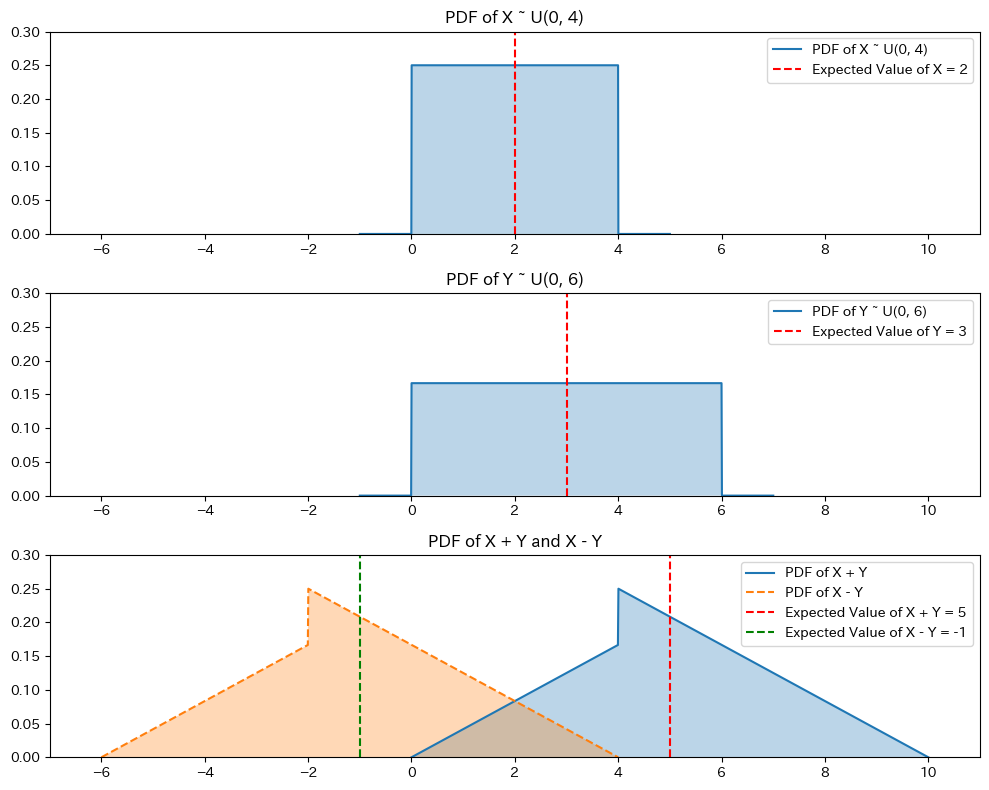

```python
# X ~ U(0,4), Y ~ U(0,6)
x_min, x_max = 0, 4
y_min, y_max = 0, 6

fx = 1 / (x_max - x_min)  # f_X(x) = 1/4
fy = 1 / (y_max - y_min)  # f_Y(y) = 1/6

# X + Y のPDF (理論値)
def f_x_plus_y(z):
    if 0 <= z <= 4:
        return z / 24
    elif 4 < z <= 10:
        return (10 - z) / 24
    else:
        return 0

# X - Y のPDF (理論値)
def f_x_minus_y(w):
    if -6 <= w <= -2:
        return (6 + w) / 24
    elif -2 < w <= 4:
        return (4 - w) / 24
    else:
        return 0

# z, w
z_values = np.linspace(0, 10, 1000)
w_values = np.linspace(-6, 4, 1000)

# Cálculo PDF
f_z_values = np.array([f_x_plus_y(z) for z in z_values])
f_w_values = np.array([f_x_minus_y(w) for w in w_values])

# Graph
x = np.linspace(-1, 11, 1000)  #
y = np.linspace(-1, 10, 1000)  #

# X ~ U(0, 4)  PDF
def uniform_pdf(x, a, b):
    return np.where((x >= a) & (x <= b), 1 / (b - a), 0)

#
fig, axs = plt.subplots(3, 1, figsize=(10, 8))

# X ~ U(0, 4)  PDF
x_vals = np.linspace(a_X - 1, b_X + 1, 1000)
pdf_X = uniform_pdf(x_vals, a_X, b_X)
axs[0].plot(x_vals, pdf_X, label=f'PDF of X ~ U({a_X}, {b_X})')
axs[0].fill_between(x_vals, pdf_X, alpha=0.3)
axs[0].axvline(E_X, color='r', linestyle='--', label=f'Expected Value of X = {E_X}')
axs[0].set_title('PDF of X ~ U(0, 4)')
axs[0].legend()

# Y ~ U(0, 6)  PDF
y_vals = np.linspace(a_Y - 1, b_Y + 1, 1000)
pdf_Y = uniform_pdf(y_vals, a_Y, b_Y)
axs[1].plot(y_vals, pdf_Y, label=f'PDF of Y ~ U({a_Y}, {b_Y})')
axs[1].fill_between(y_vals, pdf_Y, alpha=0.3)
axs[1].axvline(E_Y, color='r', linestyle='--', label=f'Expected Value of Y = {E_Y}')
axs[1].set_title('PDF of Y ~ U(0, 6)')
axs[1].legend()

axs[2].plot(z_values, f_z_values, label=f'PDF of X + Y')
axs[2].plot(w_values, f_w_values, label=f'PDF of X - Y', linestyle='--')
axs[2].fill_between(z_values, f_z_values, alpha=0.3)
axs[2].fill_between(w_values, f_w_values, alpha=0.3)
axs[2].axvline(E_X_plus_Y, color='r', linestyle='--', label=f'Expected Value of X + Y = {E_X_plus_Y}')
axs[2].axvline(E_X_minus_Y, color='g', linestyle='--', label=f'Expected Value of X - Y = {E_X_minus_Y}')
axs[2].set_title('PDF of X + Y and X - Y')
axs[2].legend()

for ax in axs[:]:
  ax.set_xlim(-7,11)
  ax.set_ylim(0,0.3)

plt.tight_layout()
plt.show()
```

和 $ Z = X + Y $ の確率密度関数： 畳み込み積分でX+Yの理論分布の計算を行う

Función de densidad de probabilidad de la zuma $ Z = X + Y $: Realizar el cálculo de la distribución teórica de X + Y mediante la integral de convolucion

$ fX+Y(z) = \int_0^4 fX(x) fY(z-x) dx $

$ 0 \leq z \leq 4: f(z) = \frac{z}{24} $

$ 4 < z \leq 10: f(z)=\frac{10-z}{24} $

## 8.1-2

2種類の部品A(寸法X)、B(寸法Y)を別々に製造し、これらを組み合わせて製品(寸法Z=X+Y)を作る工程がある。

部品AのXは正規分布 $ N(30, 2^2) $ に従い、部品BのYは正規分布 $ N(10, 1^2) $ に従う。

組み合わせ作業では、Xの大きな部品AにはYの小さな部品Bを組み合わせ、Xの小さな部品AにはYの大きな部品Bを組み合わせており、その組み合わせの実施状況はXとYの母相関係数で $ -0.75 $であることがわかっている。

寸法Zの分散を求めよ。

Hay un proceso de fabricación en el que se producen por separado dos tipos de componentes. A (dimensión X) y B (dimensión Y), y luego se combinan para formar un producto como la dimensión $ Z = X + Y $.

La dimensión X del componente A sigue una distribución normal $ N(30,2^2) $, y la dimension Y del componente B sigue una distribución normal $ N(10, 1^2) $.

Durante el proceso de ensamblaje, los componentes A con un valor alto de X se combinan con los componponetes B con un valor bajo de Y, y viceversa. Se sabe que el coeficiente de correlación poblacional entre X e Y es de $ -0.75 $.

Determinar la varianza de la dimensión Z.

$ \rho(X,Y) = \frac{Cov(X,Y)}{\sqrt{V(X) \cdot V(Y)}}$

```python
import math

# Datos de entrada
sigma_X_squared = 4  # Varianza de X (σ_X^2)
sigma_Y_squared = 1  # Varianza de Y (σ_Y^2)
rho = -0.75  # Coeficiente de correlación entre X e Y

# Cálculo de la desviación estándar
sigma_X = math.sqrt(sigma_X_squared)  # Desviación estándar de X
sigma_Y = math.sqrt(sigma_Y_squared)  # Desviación estándar de Y

# Cálculo de la covarianza
cov_XY = rho * sigma_X * sigma_Y

# Cálculo de la varianza de Z
V_Z = sigma_X_squared + sigma_Y_squared + 2 * cov_XY

print(f"la varianza de Z V(Z): {V_Z}")
```

```
la varianza de Z V(Z): 2.0
```

## 8.2

機械部品を製造している工程がある。この部品のある特性値は、母平均100.0、母標準偏差2.0の正規分布に従っている。

Hay un proceso de fabricación de componentes mecánicos. Un cierto valor característico de estos componentes sigue una distribución normal con una medida poblacional de 100.0 y una desviación estándar población de 2.0

```python
import scipy.stats as stats

# Media poblacional y desviación estándar poblacional
mu = 100.0
sigma = 2.0
```

1. サンプルをランダムに１個採取した。このサンプルの特性値が、99.0以上かつ102.0以下である確率を求めよ。
2. Se tomó una muestra aleatoria de un solo componentes. Calcula la probabilidad de que el valor característico de esta muestra sea mayor o igual a 99.0 y menor o igual a 102.0.

```python
# Rango para calcular la probabilidad de que esté entre 99.0 y 102.0
lower_bound = 99.0
upper_bound = 102.0

# Calcular la probabilidad usando la función de distribución acumulada (CDF)
probability = stats.norm.cdf(upper_bound, mu, sigma) - stats.norm.cdf(lower_bound, mu, sigma)

# Mostrar el resultado
print(f"la probabilidad de que el valor de la característica esté entre 99.0 y 102.0 : {probability:.2f}")
```

```
la probabilidad de que el valor de la característica esté entre 99.0 y 102.0 : 0.53
```

2. サンプルをランダムに4個採取した。これらのサンプルの特性値の平均値が、99.5以上かつ100.5以下である確率を求めよ。
3. Se tomaron aleatoriamente cuatro muestras. Calcula la probabilidad de que la media de los valores característicos de estas muestras sea mayor o igual a 99.5 y menor o igual a 100.5.

```python
# Tamaño de la muestra
n = 4

# Desviación estándar de la media
sigma_sample_mean = sigma / (n ** 0.5)

# Probabilidad de que la media muestral esté entre 99.5 y 100.5
lower_bound = 99.5
upper_bound = 100.5

# Calcular la probabilidad usando la función de distribución acumalada (CDF)
probability = stats.norm.cdf(upper_bound, mu, sigma_sample_mean) - stats.norm.cdf(lower_bound, mu, sigma_sample_mean)

# Mostrar el resultado
print(f"la probabilidad de que el promedio del valor de la característica de la muestra esté entre 99.5 y 100.5: {probability:.2f}")
```

```
la probabilidad de que el promedio del valor de la característica de la muestra esté entre 99.5 y 100.5: 0.38
```

3. サンプルをランダムに11個採取した。これらのサンプルの特性値の不偏分散Vが1.3以下である確率を求めよ。
4. Se tomaron aleatoriamente once muestras. Calcula la probabilidad de que la varianza insesgada V de los valores característicos de estas muestras sea menor o igual a 1.3.

```python
# Tamaño de la muestra
n = 11

# Desviación estándar probacional
sigma = 2.0

# Límite superior de la varianza insesgada
V_upper = 1.3

# Grados de libertad de la distribución chi-cuadrado
df = n - 1

# Varianza de la muestra
sample_variance = (sigma ** 2)

# Calcular la probabilidad de que la varianza insesgada sea menor o igual
# a 1.3 usando la distribución chi-cuadrado
chi2_value = (n - 1) * V_upper / sample_variance
probability = stats.chi2.cdf(chi2_value, df)

# Mostrar el resultado
print(f"la probabilidad de que la varianza insesgada de la muestra sea menor o igual a 1.3 : {probability:.4f}")
```

```
la probabilidad de que la varianza insesgada de la muestra sea menor o igual a 1.3 : 0.0251
```

4. サンプルをランダムに採取した時、これらのサンプルの特性値の不偏分散Vが3.0以下となる確率を25%以下にしたい。この条件を満足する最も少ないサンプル数ｎを求めよ。
5. Cuando se toma una muestra aleatoria, se desea que la probabilidad de que la varianza insesgada $ V $ de los valores característicos de estas muestras sea menor o igual a 3.0 sea del 25% o menos. Detemina el tamaño de muestra mínimo $ n $ que satisface esta condición.

```python
# Desviación estándar poblacional
sigma = 2.0

# Límite superior de la varizanza insesgada
V_upper = 3.0

# Probabilidad objetivo
target_probability = 0.25

# Tamaño de muestra inicial
n = 2

# Encontrar el tamaño de muestra mínimo que cumple la condición
while True:
    df = n - 1  # Grado de libertad
    sample_variance = (sigma ** 2)

    # Calcular la probabilidad de que la varianza insesgada se menor o
    # igual a 3.0 usando la distribución chi-cuadrado
    chi2_value = (n - 1) * V_upper / sample_variance
    probability = stats.chi2.cdf(chi2_value, df)

    # Si la probabilidad es menor o igual al objetivo, mostrar el tamaño de
    # muestra actual
    if probability <= target_probability:
        break

    # Aumentar el tamaño de muestra y proceder a la siguiente iteración
    n += 1

# Mostrar el resultado
print(f"el tamaño mínimo de muestra para que la probabilidad de que la varianza \ninsesgada del valor de la característica de la muestra \nsea menor o igual a {V_upper:.1f} sea del {target_probability*100:.1f}% o menos: {n}")
```

```
el tamaño mínimo de muestra para que la probabilidad de que la varianza
insesgada del valor de la característica de la muestra
sea menor o igual a 3.0 sea del 25.0% o menos: 18
```

5. 上限確率 $ P = 1-0.25=0.75 $ に対する $ \phi $ と $ \chi^2 $ の組み合わせの計算表を作成する。
6. Crear una tabla de cálculo de combinaciones de $ \phi $ y $ \chi^2 $ para la probabilidad límite $ P = 1-0.25 = 0.75 $.

```python
def calculate_chi_square(df, P):
    chi2_value = stats.chi2.isf(P, df)
    return chi2_value

tab = pd.DataFrame({"n":[12,17,18,20,26]})
tab["df"] = tab["n"]-1
tab["chi^2"] = calculate_chi_square(tab["df"], 0.75)
tab["V"] = tab["chi^2"]*4/tab["df"]
tab[['chi^2','V']] = tab[['chi^2','V']].apply(lambda c: c.map(lambda x: round(x, 2)))

print("Tabla de cálculo")
tab
```

```
Tabla de cálculo
```

|  | n | df | chi^2 | V |
| --- | --- | --- | --- | --- |
| 0 | 12 | 11 | 7.58 | 2.76 |
| 1 | 17 | 16 | 11.91 | 2.98 |
| 2 | 18 | 17 | 12.79 | 3.01 |
| 3 | 20 | 19 | 14.56 | 3.07 |
| 4 | 26 | 25 | 19.94 | 3.19 |

## 8.3

ガラス瓶に洋酒を自動充填している工程があり、充填する洋酒の洋酒の体積を一定になるように制御している。充填された洋酒の体積は母平均 $ 735.0 ml $,母分散 $ 1.0^2 (ml)^2 $ の正規分布に従い、ガラス瓶の内容積は母平均 $ 750.0 ml $、母分散 $ 3.0^2 (ml)^2 $ の正規分布に従っており、互いに独立とする。

En un proceso de llenado automático de licor en botellas de vidrio, se controla el volumen del licor llenado para que sea constante. El volumen del licor llenado sigue una distribución normal con una media poblacional de $ 735.0 ml $ y una varianza poblacional de $ 1.0^2 (ml)^2 $. El volumen interno de las botellas de vidrio sigue una distribución normal con una media poblacional de $ 750.0 ml $ y una varianza poblacional de $ 3.0^2 (ml)^2 $, y ambos son estadísticamente independientes.

1. 充填される洋酒瓶の空隙部の容積の母平均と母分散を求めよ。
2. Determina la media poblacional y la varianza poblacional del volumen de espacio vacío en las botellas de licor llenadas.

```python
# Media poblacional del volumen interno de la botella de vidrio y
# del volumen de licor llenado
mean_volume_bottle = 750.0  # Media poblacional del volumen interno de la botella de vidrio (mL)
mean_volume_liquor = 735.0  # Media poblacional del volumen del licor (mL)

# Calcular la media poblacional del volumen del espacio vacío
mean_void_volume = mean_volume_bottle - mean_volume_liquor

# Mostrar el resultado
print(f"Media poblacional del volumen del espacio vacío en \nlas botellas de licor lenadas: {mean_void_volume} mL")

# Varianza poblacional del volumen interno de la botella de vidrio y
# del volumen de licor llenado
variance_volume_bottle = 3.0**2  # Varianza poblacional del volumen interno de la botella de vidrio (mL^2)
variance_volume_liquor = 1.0**2  # Varianza poblacional del volumen del licor (mL^2)

# Calcular la varianza poblacional del volumen del espacio vacío
variance_void_volume = variance_volume_bottle + variance_volume_liquor

# Mostrar el resultado
print(f"Varianza poblacional del volumen del espacio vacío en \nlas botellas de licor llenadas: {variance_void_volume} (mL^2)")
```

```
Media poblacional del volumen del espacio vacío en
las botellas de licor lenadas: 15.0 mL
Varianza poblacional del volumen del espacio vacío en
las botellas de licor llenadas: 10.0 (mL^2)
```

2. 空隙部の容積が $ 9.0 ml $ 以上かつ $ 21.0 ml $ 以下の瓶を適合品としている。不適合品の発生する確率を求めよ。
3. Se consideran productos conformes las botellas cuyo volumen del espacio vacío está entre $ 9.0 ml $ y $ 21.0 ml $. Calcula la probabilidad de que se generen productos no conformes.

```python
# Media y varianza poblacional del volumen del licor
mu_X = 735.0
sigma_X = 1.0

# Media y varianza poblacional del volumen interno de la botella de vidrio
mu_Y = 750.0
sigma_Y = 3.0

# Media y varianza poblacional del volumen del espacio vacío
mu_Z = mu_Y - mu_X
sigma_Z = np.sqrt(sigma_X**2 + sigma_Y**2)

# Calcular la probabilidad de que el volumen del espacio vacío esté entre
# 9.0 ml y 21.0 ml
lower_bound = 9.0
upper_bound = 21.0

# Calcular la probabilidad de que el volumen del espacio vacío esté entre 9.0 ml y 21.0 ml
probabilidad = norm.cdf(upper_bound, mu_Z, sigma_Z) - norm.cdf(lower_bound, mu_Z, sigma_Z)

# Probabilidad de productos no conformes (fuera de los límites)
probabilidad_no_conforme = 1 - probabilidad

# Mostrar el resultado
print(f'La probabilidad de que el volumen del espacio vacío esté fuera de ese rango \n(productos no conformes) es: {probabilidad_no_conforme*100:.1f}%')
```

```
La probabilidad de que el volumen del espacio vacío esté fuera de ese rango
(productos no conformes) es: 5.8%
```

3. ある時、特殊なセンサーを導入し空隙部の容積が一定になるように充填量を制御する方式に変更した。空隙部の容積の母平均は15.0 mlとする。この時、空隙部の容積の規格が9.0 ml以上かつ21.0 ml以下である確率を求め、不適合品の発生する確率が1.0 %以下になるように空隙部の母分散を求めよ。
4. En un momento dado, se introdujo un sensor especial y se cambió el método de control del volumen de llenado para que el volumen del espacío vacío sea constante. Se supone que la media poblacional del volumen del espacio vacío es de 15.0 ml. En este caso, calcule la probabilidad de que el volumen del espacio vacío entre 9.0 ml y 21.0 ml, y determine la varianza poblacional del volumen del espacio vacío de manera que la probabilidad de que se produzcan productos defectuosos sea inferior al 1.0 %.

```python
from scipy.optimize import brentq
import scipy.stats as stats

# Parámetros
mu_X = 735.0  # Media poblacional del volumen del licor
sigma_X = 1.0  # Varianza poblacional del volumen del licor

mu_Y = 750.0  # Media poblacional del volumen interno de la totella de vidrio
sigma_Y = 3.0  # Varianza poblacional de volumen interno de la botella de vidrio

# Nueva media poblacional del volumen del espacio vacío
mu_Z_new = 15.0

# Probabilidad de que el volumen del espacio vacío este 9.0 ml y 21.0 ml,
# garantizando que sea mayor al 99%
lower_bound = 9.0
upper_bound = 21.0
required_probability = 0.99

# Función para calcular la varianza del volumen del espacio vacio
def probability_defective(sigma_Z_squared):
    if sigma_Z_squared <= 0:
        return 1.0  # Valores de varianza menores o iguales a 0 son inválidos

    # Desviación estándar del volumen de espacio vacío Z
    sigma_Z = np.sqrt(sigma_Z_squared)

    # Distribución de probabilidad del volumen del espacio vacío Z
    prob_within_range = stats.norm.cdf(upper_bound, mu_Z_new, sigma_Z) - stats.norm.cdf(lower_bound, mu_Z_new, sigma_Z)

    # Probabilidad de productos defectuosos
    prob_defective = 1 - prob_within_range

    return prob_defective - (1 - required_probability)

# Para garantizar que la varianza sea mayor que 0, se establece un valor mínimo
lower_bound_variance = 0.01

# Evaluar la función para valores mayores o iguales a 0 y buscar la solución
optimal_variance = brentq(probability_defective, lower_bound_variance, 1000)

# Resultados
optimal_std_dev = np.sqrt(optimal_variance)
optimal_prob_defective = probability_defective(optimal_variance) + (1 - required_probability)

# Mostrar resultados
print(f"Varianza poblacional del volumen del espacio vacío: {optimal_variance:.1f} ml^2")
```

```
Varianza poblacional del volumen del espacio vacío: 5.4 ml^2
```

## 8.4

1. $ u $ が正規分布 $ N(0, 1^2) $ に従うとき、$ u^2 $ は自由度 $ \phi = 1 $ の $ \chi^2 $ 分布に従う
2. Si $ u $ sigue una distribución normal $ N(0,1^2) $, entonces $ u^2 $ sigue una distribución $ \chi^2 $ con un grado de libertad $ (\phi = 1) $.

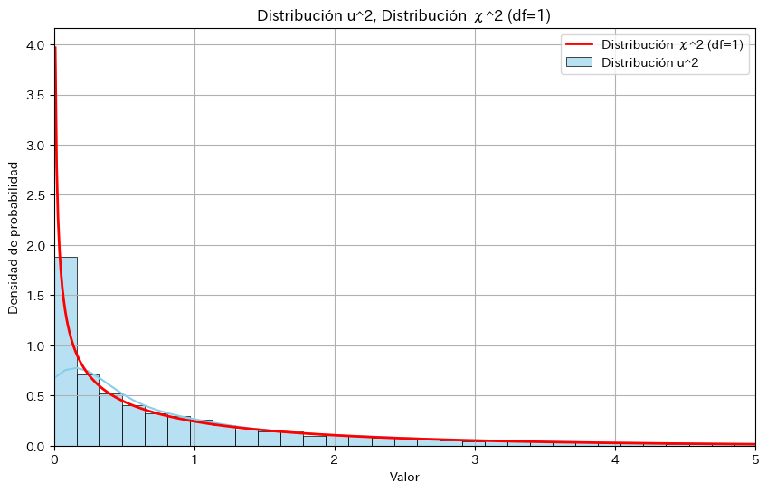

```python
import seaborn as sns
from scipy.stats import chi2, norm

# Tamaño de la muestra
n_samples = 10000

# Generar muestras de la distribución normal N(0, 1^2)
u = np.random.normal(0, 1, n_samples)

# Calcula el cuadrado de u
u_squared = u ** 2

# Superponer la distribución χ^2
x = np.linspace(0, 10, 1000)
chi2_pdf = chi2.pdf(x, df=1)

# Dibujar el histograma
plt.figure(figsize=(10, 6))
sns.histplot(u_squared, bins=100, stat="density", color='skyblue', kde=True, label='Distribución u^2', alpha=0.6)

# Superponer la distribuchio χ^2
plt.plot(x, chi2_pdf, color='red', label='Distribución χ^2 (df=1)', lw=2)

# Decorar el gráfico
plt.title('Distribución u^2, Distribución χ^2 (df=1)')
plt.xlabel('Valor')
plt.ylabel('Densidad de probabilidad')
plt.legend()
plt.grid()
plt.xlim(0, 5)

# Mostrar el gráfico
plt.show()
```

2. $ \phi = \infty $ のｔ分布は、正規分布 $ N(0,1^2) $ と一致する
3. La distribución $ t $ con $ \phi = \infty $ coincide con la distribución normal $ N(0,1^2) $.

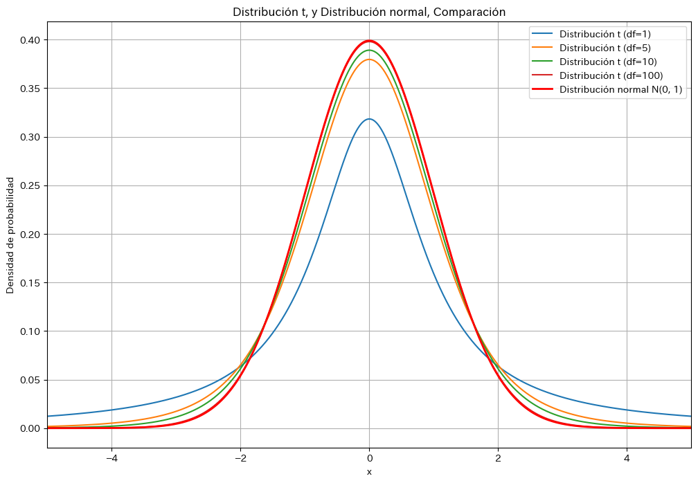

```python
from scipy.stats import t, norm

# Establecer el rango del eje x
x = np.linspace(-5, 5, 1000)

# Configurar los grado sde libertad
degrees_of_freedom = [1, 5, 10, 100]  # 100 representa apoximadamente infinito

# Dibujar el gr[afico]
plt.figure(figsize=(12, 8))

# Dibujar la distribución t y la distribución normal
for df in degrees_of_freedom:
    plt.plot(x, t.pdf(x, df), label=f'Distribución t (df={df})')

# Dibujar la distribución normal
plt.plot(x, norm.pdf(x, 0, 1), label='Distribución normal N(0, 1)', color='red', lw=2)

# Decorar gráfico
plt.title('Distribución t, y Distribución normal, Comparación')
plt.xlabel('x')
plt.ylabel('Densidad de probabilidad')
plt.legend()
plt.grid()
plt.xlim(-5, 5)

# Mostrar el gráfico
plt.show()
```

3. $ t $ が自由度 $ \phi $ の $ t $ 分布に従うとき、$ t^2 $ は自由度 $ \phi_1 = 1 $, $ \phi_2 = \phi $ のF分布に従う
4. Si $ t $ sigue una distribución $ t $ con $ \phi $ grados de libertad, entonces $ t^2 $ sigue una distribución $ F $ con $ \phi_1 $ y $ \phi_2 = \phi $ grados de libertad.

t(1,P)^2 = F(1, 1:P)

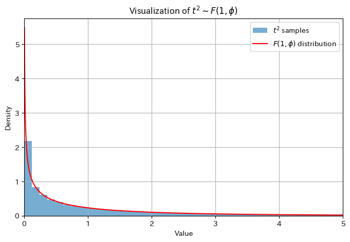

```python
import scipy.stats as stats

# Configurar los grados de libertad
phi = 10  # Grados de libertad de la distribución t
phi1 = 1  # Grados de libertad 1 de la distribución F
phi2 = phi  # Grados de libertad 2 de la distribución F

# Generar muestras de la distribución t
t_samples = np.random.standard_t(df=phi, size=100000)
t_squared_samples = t_samples**2  # Elevar al cuadrado los valores de t

# Calcular la función de densidad de probabilidad teórica de la distribución F
x = np.linspace(0, 5, 1000)
f_pdf = stats.f.pdf(x, phi1, phi2)

# Dibujar el histograma
plt.figure(figsize=(8, 5))
plt.hist(t_squared_samples, bins=500, density=True, alpha=0.6, label=r'$t^2$ samples')
plt.plot(x, f_pdf, 'r-', label=r'$F(1, \phi)$ distribution')
plt.xlim(0,5)

# Decorar el gráfico
plt.xlabel('Value')
plt.ylabel('Density')
plt.title(r'Visualization of $t^2 \sim F(1, \phi)$')
plt.legend()
plt.grid()
plt.show()
```

4. $ \chi^2 $ が自由度 $ \phi $ の $ \chi^2 $ 分布に従うとき、$ \chi^2 / \phi $ は自由度 $ \phi_1 = \phi $, $ \phi_2 = \infty $ のF分布にしたがう
5. Cuando $ \chi^2 $ sigue una distribución $ \chi^2 $ con grados de libertad $ \phi $, entonces $ \chi^2 / \phi $ sigue una distribución F con grados de libertad $ \phi_1 = \phi $ y $ \phi_2 = \infty $.

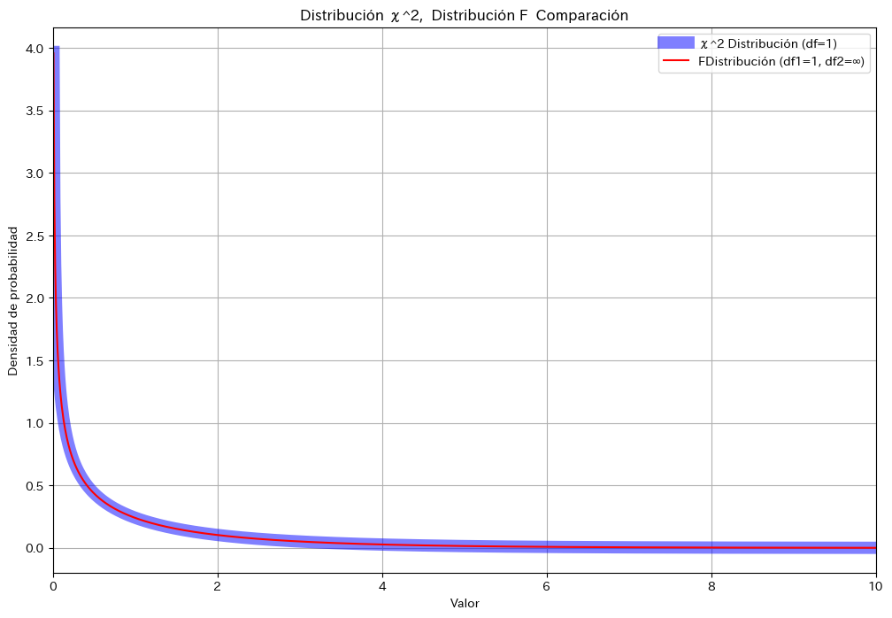

```python
from scipy.stats import chi2, f

# Establecer el rango del eje x
x = np.linspace(0, 10, 1000)

# Configurar el rango de libertad
df_chi2 = 1
df_f1 = 1
df_f2 = 100  # Establecer un valor de grados de libertad cercano a infinito

# Calcular la función de densidad de probabilidad de la distribución χ^2
chi2_pdf = chi2.pdf(x, df_chi2)

# Calcular la función de densidad de probabilidad de la distribución F
f_pdf = f.pdf(x, df_f1, df_f2)

# Dibujar el gráfico
plt.figure(figsize=(12, 8))

# Dibujar la distribución χ^2
plt.plot(x, chi2_pdf, label='χ^2 Distribución (df=1)', linewidth=10, alpha=0.5, color='blue')

# Dibujar la distribución F
plt.plot(x, f_pdf, label='FDistribución (df1=1, df2=∞)', color='red')

# Decorar el gráfico
plt.title('Distribución χ^2,  Distribución F  Comparación')
plt.xlabel('Valor')
plt.ylabel('Densidad de probabilidad')
plt.legend()
plt.grid()
plt.xlim(0, 10)

# Mostrar el gráfico
plt.show()
```

# 8.5

1. 母不適合品率 $ P = 0.1 $ の工程からサンプルを $ n = 4 $ 個ランダムに抜き取った。この時、サンプル中に不適合品が $ x = 1 $ 入っている確率を計算せよ
2. Se extraen aleatorioamente $ n = 4 $ muestras de un proceso con una tasa de productos no conformes de $ P = 0.1 $. Calcule la probabilidad de que haya $ x = 1 $ producto no conforme en la muestra.

```
Probabilidad de que haya 1 artículo defectuoso en la muestra: 0.2916
```

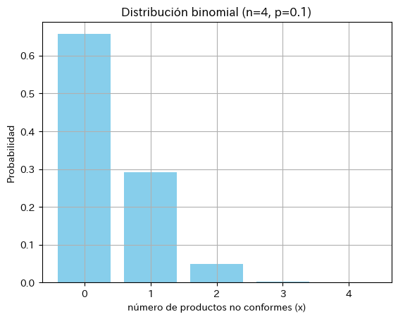

```python
import scipy.stats as stats

# Tasa de defectos en la población p
p = 0.1

# Tamaño de la muestra n
n = 4

# Número de defectuosos x
x = 1

# Calcular la probabilidad de que haya x=1 defectuoso en la muestra utilizando
# la distribución binomial
probability = stats.binom.pmf(x, n, p)

print(f"Probabilidad de que haya 1 artículo defectuoso en la muestra: {probability:.4f}")

# Calcular la probabilidad de cada valor de x en la distribución binomial
# para el rango de x (de 0 a n)
x_values = np.arange(0, n + 1)

# Calcular la probabilidad de cada valor de x en la distribución binomial
# para el rango de x (de 0 a n)
probabilities = stats.binom.pmf(x_values, n, p)

# Crear un gráfico de barras de la distribución binomial
plt.bar(x_values, probabilities, color='skyblue')
plt.xlabel('número de productos no conformes (x)')
plt.ylabel('Probabilidad')
plt.title('Distribución binomial (n=4, p=0.1)')
plt.xticks(x_values)
plt.grid(True)

# Mostrar el gráfico
plt.show()
```

2. 電子部品Eの寿命は、故障率を表すパラメータ $ \lambda = 1/100 (時間^{-1}) $ の指数分布に従っている。この電子部品の寿命Xが100時間から200時間である確率を求めよ。
3. La vida útil del componente electrónico E sigue una distribución exponencial con un parámetro de tasa de fallos $ \lambda = 1/100 (hora^{-1}) $. Calcule la probabilidad de que la vida útil de este componente, X, esté entre 100 horas y 200 horas.

```python
import scipy.stats as stats

# Configuración de parámetros
lambda_param = 1 / 100  # Tasa de fallos λ
t1 = 100  # Límite inferior de la vida útil
t2 = 200  # Límite superior de la vida útil

# Calcular la probabilidad utilizando la función acumulada (CDF)
# de la distribución exponencial
# CDF(x) = 1 - e^(-λx)
prob_t1 = 1 - np.exp(-lambda_param * t1)
prob_t2 = 1 - np.exp(-lambda_param * t2)

# Probabilidad de que la vida útil esté entre 100 y 200 horas
prob = prob_t2 - prob_t1

# Mostrar el resultado
print(f"la probabilidad de que la vida útil esté entre 100 y 200 horas: {prob:.2f}")
```

```
la probabilidad de que la vida útil esté entre 100 y 200 horas: 0.23
```

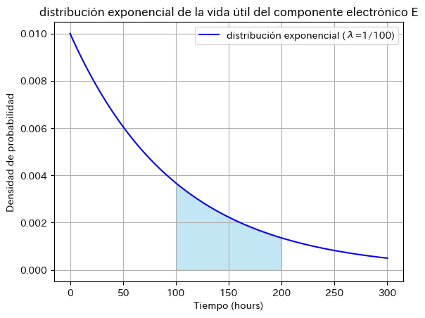

```python
# Establecer el rango de vida útil (de 0 a 300 tiempos)
x_values = np.linspace(0, 300, 500)

# Calcular la función de densidad de probabilidad (PDF) de la distribución exponencial
pdf_values = stats.expon.pdf(x_values, scale=1/lambda_param)

# Crear el gráfico
plt.plot(x_values, pdf_values, label='distribución exponencial (λ=1/100)', color='blue')
plt.fill_between(x_values, pdf_values, where=((x_values >= t1) & (x_values <= t2)), color='skyblue', alpha=0.5)

# Configurar los detalles del gráfico
plt.title('distribución exponencial de la vida útil del componente electrónico E')
plt.xlabel('Tiempo (hours)')
plt.ylabel('Densidad de probabilidad')
plt.legend()
plt.grid(True)

# Mostrar el gráfico
plt.show()
```